# Predicting human activity

Adán López

25/9/2020

## Data

```r
download.file("https://d396qusza40orc.cloudfront.net/predmachlearn/pml-training.csv",
               destfile="training.csv")
download.file("https://d396qusza40orc.cloudfront.net/predmachlearn/pml-testing.csv",
               destfile="testing.csv")
training<-read.csv("training.csv"); testing<-read.csv("testing.csv")
c<-c(7:11,37:49,60:68,84:86,102,113:124,140,151:159)
train<-as.data.frame(matrix(ncol = length(c), nrow = nrow(training)))
j<-1 ## Now I change the class to numeric data for both datasets
for(i in c) {
      train[,j]<-as.numeric(training[,i]);
      testing[,j]<-as.numeric(testing[,i])
      j<-j+1}
train$classe<-as.factor(training$classe)
tclasse<-testing$classe #???
testing<-testing[,c]
names(train)[1:53]<-names(testing)
```

I extracted only the variables of interest, which had relevant information and without missing values. I used the Random forest method for the classification. A problem with this could be the overfitting, which I reduce by cross validation. I preprocessed by principal component analysis, centering and scaling, in order to use less variables and transforming them in the same units.

```r
library(caret); set.seed(123); library(doParallel)
cluster <- makeCluster(detectCores() - 1)
registerDoParallel(cluster)
fitControl <- trainControl(method = "cv", number = 5,
                           allowParallel = T, preProcOptions = list(thresh = 0.95))
fit1<-train(classe~.,train, method="rf",trControl=fitControl,
            preProcess=c("pca","center","scale"))
stopCluster(cluster)
registerDoSEQ()
V<-predict(fit1,newdata=testing)
fit1[11][[1]]
```

```
##
## Call:
##  randomForest(x = x, y = y, mtry = param$mtry)
##                Type of random forest: classification
##                      Number of trees: 500
## No. of variables tried at each split: 2
##
##         OOB estimate of  error rate: 1.48%
## Confusion matrix:
##      A    B    C    D    E class.error
## A 5556    8   12    1    3 0.004301075
## B   38 3729   26    0    4 0.017908875
## C    7   33 3361   20    1 0.017825833
## D    1    3  106 3101    5 0.035758706
## E    1    3    7   11 3585 0.006099251
```

In the table above you can see the **estimated error rate**, which should be similar to the out of sample error, since for the **cross validation** I took 5 resamples of the training data.

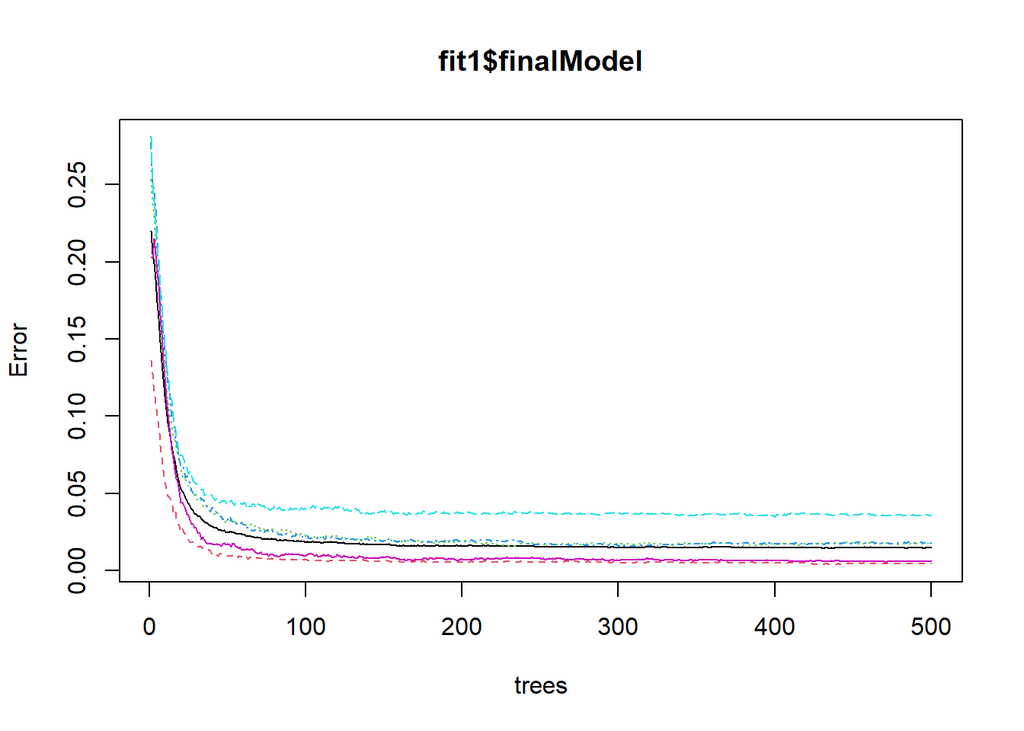

At the end, we can see that after 200 trees there is no significant improvement in the error. The **prediction for the 20 cases** in the testing set are: D, E, E, E, E, E, E, E, E, E, E, E, E, E, E, E, D, E, D, D

## Reference

Ugulino, W.; Cardador, D.; Vega, K.; Velloso, E.; Milidiu, R.; Fuks, H. [Wearable Computing: Accelerometers’ Data Classification of Body Postures and Movements](http://groupware.les.inf.puc-rio.br/work.jsf?p1=10335). Proceedings of 21st Brazilian Symposium on Artificial Intelligence. Advances in Artificial Intelligence - SBIA 2012. In: Lecture Notes in Computer Science. , pp. 52-61. Curitiba, PR: Springer Berlin / Heidelberg, 2012. ISBN 978-3-642-34458-9. DOI: 10.1007/978-3-642-34459-6_6. Cited by 2 (Google Scholar)

Read more: [here](http://groupware.les.inf.puc-rio.br/har#ixzz6Z3ln0Rkf)